# Regresion lineal simple

Gabriel Tehozol Hernández

15 de febrero 2023

# Modelo convencional

En este markdown realizaremos un modelo de regresión simple

## Importamos librerías

```r
library(caTools)
library(tidyverse)
library(car)
library(boot)
library(QuantPsyc)
library(ggplot2)
```

## Obtenemos datos

En esta ocasión vamos a oobtener los datos de una base de datos radicada en un repositorio en GitHub, definimos la variable donde hallaremos la liga de la base y posteriormente la leemos y observamos los primeros 5 datos

```r
liga <- "https://raw.githubusercontent.com/AnnaShestova/salary-years-simple-linear-regression/master/Salary_Data.csv"
datos <- read.csv(liga)
head(datos)
```

|  | YearsExperience | Salary |
| --- | --- | --- |
| 1 | 1.1 | 39343 |
| 2 | 1.3 | 46205 |
| 3 | 1.5 | 37731 |
| 4 | 2.0 | 43525 |
| 5 | 2.2 | 39891 |
| 6 | 2.9 | 56642 |

```r
str(datos)
```

```
## 'data.frame':    30 obs. of  2 variables:
##  $ YearsExperience: num  1.1 1.3 1.5 2 2.2 2.9 3 3.2 3.2 3.7 ...
##  $ Salary         : num  39343 46205 37731 43525 39891 ...
```

## Tratamiento de datos

Renombramos las columnas donde: * Añexp = Años de experiencia * Sal = Salario

```r
names(datos) <- c("Añexp", "Sal")
head(datos)
```

|  | Añexp | Sal |
| --- | --- | --- |
| 1 | 1.1 | 39343 |
| 2 | 1.3 | 46205 |
| 3 | 1.5 | 37731 |
| 4 | 2.0 | 43525 |
| 5 | 2.2 | 39891 |
| 6 | 2.9 | 56642 |

## Relizamos el modelo

```r
modelo = lm(Sal~Añexp, data = datos, na.action=na.exclude)
summary(modelo)
```

```
##
## Call:
## lm(formula = Sal ~ Añexp, data = datos, na.action = na.exclude)
##
## Residuals:
##     Min      1Q  Median      3Q     Max
## -7958.0 -4088.5  -459.9  3372.6 11448.0
##
## Coefficients:
##             Estimate Std. Error t value Pr(>|t|)
## (Intercept)  25792.2     2273.1   11.35 5.51e-12 ***
## Añexp         9450.0      378.8   24.95  < 2e-16 ***
## ---
## Signif. codes:  0 '***' 0.001 '**' 0.01 '*' 0.05 '.' 0.1 ' ' 1
##
## Residual standard error: 5788 on 28 degrees of freedom
## Multiple R-squared:  0.957,  Adjusted R-squared:  0.9554
## F-statistic: 622.5 on 1 and 28 DF,  p-value: < 2.2e-16
```

## Interpretación del modelo

Podemos interpretar que por cada año adicional de experiencia, el salario aumentará en 9450 unidades monetarias. Es decir, cuando carecemos de años de experiencia el salario sería de 25792.2 unidades monetarias

```r
sqrt(0.957)
```

```
## [1] 0.9782638
```

## Gráficamos

Realizamos una gráfica de puntos y gráficamos la regresión

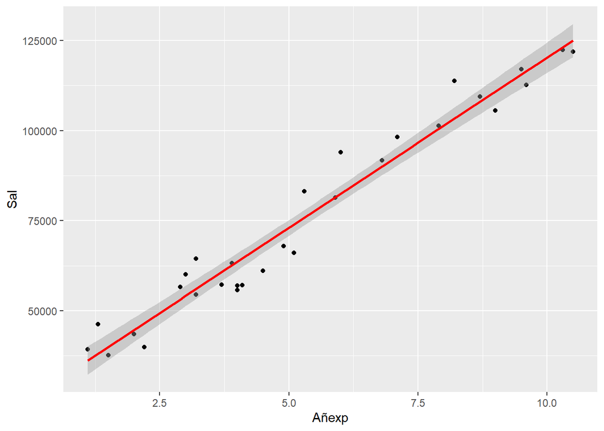

```r
grafica = ggplot(data = datos, mapping = aes(Añexp, Sal)) +
   geom_point() +
   geom_smooth(method = 'lm', colour = 'Red')
grafica
```

# Modelo de aprendizaje autómatico (Machine Learning)

## Entrenamiento del modelo

Se separan los datos que se usaran para entrenar el modelo y lo que posteriormente serán usados para probarlo

```r
set.seed(123)
split = sample.split(datos$Sal, SplitRatio = 2/3)
dato_entreamiento = subset(datos, split == TRUE)
dato_prueba = subset(datos, split == FALSE)
```

## Definimos el modelo

Definimos un modelo de regresión lineal simple

```r
modelo_ml = lm(Sal~Añexp, data = dato_entreamiento)
preds = predict(modelo_ml, newdata = dato_prueba)
summary(modelo_ml)
```

```
##
## Call:
## lm(formula = Sal ~ Añexp, data = dato_entreamiento)
##
## Residuals:
##     Min      1Q  Median      3Q     Max
## -7325.1 -3814.4   427.7  3559.7  8884.6
##
## Coefficients:
##             Estimate Std. Error t value Pr(>|t|)
## (Intercept)    25592       2646   9.672 1.49e-08 ***
## Añexp           9365        421  22.245 1.52e-14 ***
## ---
## Signif. codes:  0 '***' 0.001 '**' 0.01 '*' 0.05 '.' 0.1 ' ' 1
##
## Residual standard error: 5391 on 18 degrees of freedom
## Multiple R-squared:  0.9649, Adjusted R-squared:  0.963
## F-statistic: 494.8 on 1 and 18 DF,  p-value: 1.524e-14
```

## Interpretación modelo lm de aprendizaje autómatico

Podemos interpretar que por cada año adicional de experiencia, el salario aumentará en 9365 unidades monetarias. Es decir, cuando carecemos de años de experiencia el salario sería de 25592 unidades monetarias

## Graficamos el modelo

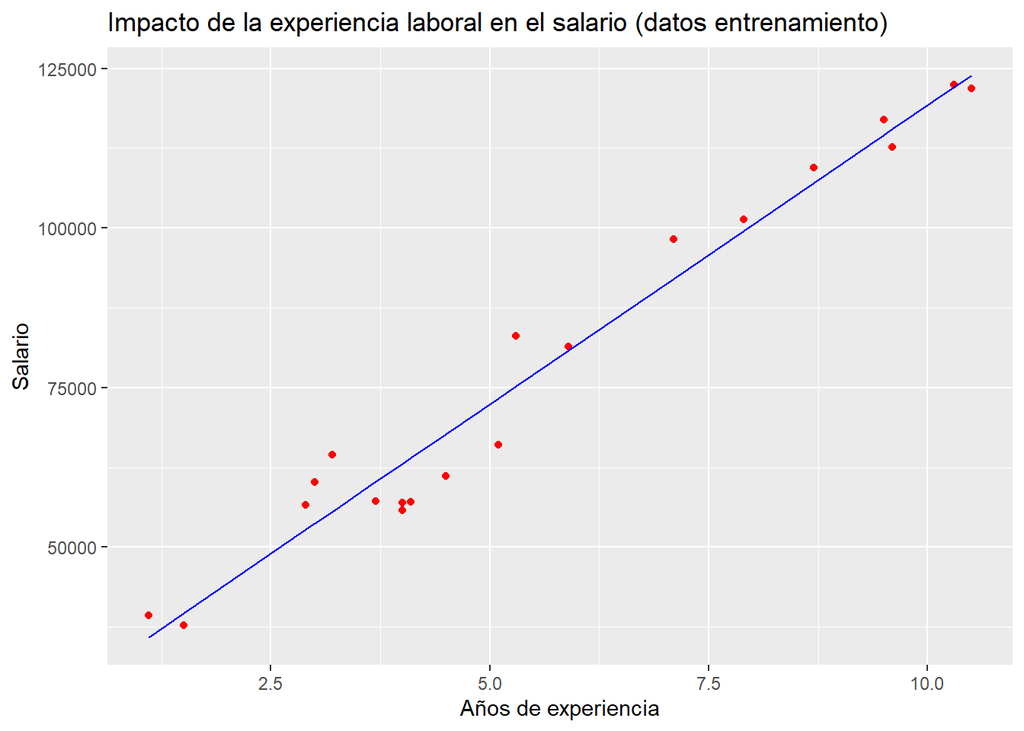

```r
ggplot() +
  geom_point(aes(x = dato_entreamiento$Añexp, y = dato_entreamiento$Sal),
             colour = 'red') +
  geom_line(aes(x = dato_entreamiento$Añexp, y = predict(modelo_ml, newdata = dato_entreamiento)),
            colour = 'blue') +
  geom_smooth(method = 'lm') +
  ggtitle('Impacto de la experiencia laboral en el salario (datos entrenamiento)') +
  xlab('Años de experiencia') +
  ylab('Salario')
```

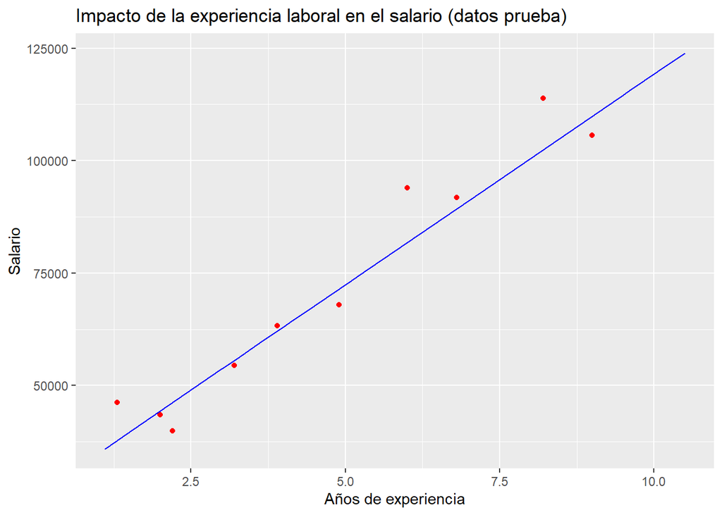

```r
ggplot() +
  geom_point(aes(x = dato_prueba$Añexp, y = dato_prueba$Sal),
             colour = 'red') +
  geom_line(aes(x = dato_entreamiento$Añexp, y = predict(modelo_ml, newdata = dato_entreamiento)),
            colour = 'blue') +
  geom_smooth(method = 'lm') +
  ggtitle('Impacto de la experiencia laboral en el salario (datos prueba)') +
  xlab('Años de experiencia') +
  ylab('Salario')
```

Es posible observar de manera gráfica, que el modelo de datos entrenado se adapta a los datos prueba, lo que comprueba la eficacia de los modelos de aprendizaje automático.